# Assignment 2

2024-09-25

## 1) Murrell.R

Change pch change the shape of the data points.

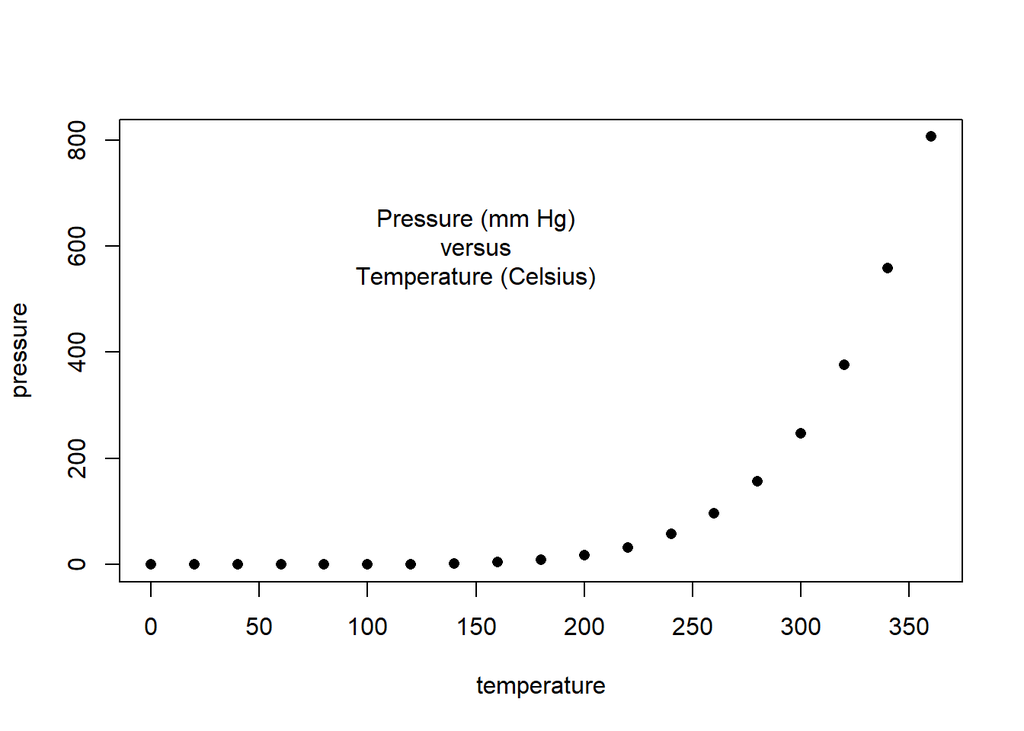

```r
plot(pressure, pch=16)
text(150, 600,
     "Pressure (mm Hg)\nversus\nTemperature (Celsius)")
```

```r
par(mfrow=c(3, 2))
x <- c(0.5, 2, 4, 8, 12, 16)
y1 <- c(1, 1.3, 1.9, 3.4, 3.9, 4.8)
y2 <- c(4, .8, .5, .45, .4, .3)
```

### Including Plots

Change cex change size of the points, bg, color of the points, fg, color of the axis

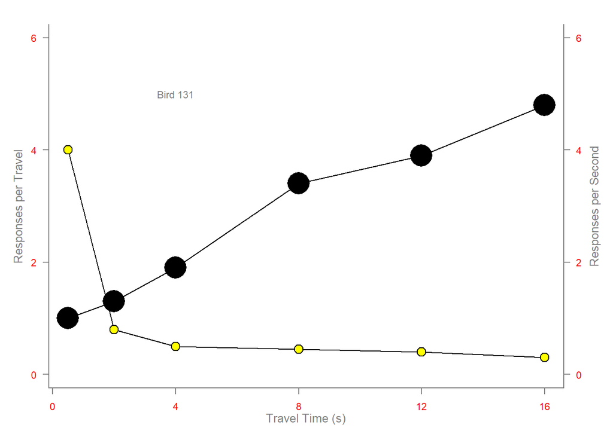

```r
par(las=1, mar=c(4, 4, 2, 4), cex=.7)
plot.new()
plot.window(range(x), c(0, 6))
lines(x, y1)
lines(x, y2)
points(x, y1, pch=16, cex=5) # Try different cex value?
points(x, y2, pch=21, bg="yellow", cex=2)  # Different background color
par(col="blue", fg="gray50", col.axis="red")
axis(1, at=seq(0, 16, 4)) # X-axis, min, max, gap
axis(2, at=seq(0, 6, 2))
axis(4, at=seq(0, 6, 2))
box(bty="u")
mtext("Travel Time (s)", side=1, line=2, cex=0.8)
mtext("Responses per Travel", side=2, line=2, las=0, cex=0.8)
mtext("Responses per Second", side=4, line=2, las=0, cex=0.8)
text(4, 5, "Bird 131")
```

```r
par(mar=c(5.1, 4.1, 4.1, 2.1), col="black", fg="black", col.axis="black")
```

### Histogram

1. Stand for the difference between the points of the x curve x <- seq(-3.5, 3.5, .1)
2. FALSE means plots probability densities (Total Sum =1) rather than frequency hist(Y, breaks=seq(-3.5, 3.5), ylim=c(0, 0.5), col=“purple”, freq=FALSE)

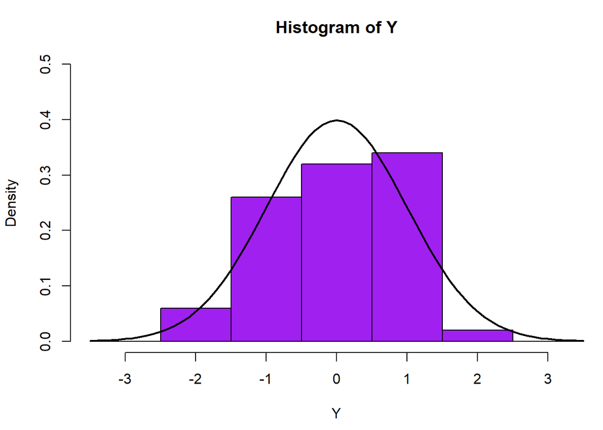

```r
Y <- rnorm(50)
# Make sure no Y exceed [-3.5, 3.5]
Y[Y < -3.5 | Y > 3.5] <- NA # Selection/set range
x <- seq(-3.5, 3.5, .1)
dn <- dnorm(x)
par(mar=c(4.5, 4.1, 3.1, 0))
hist(Y, breaks=seq(-3.5, 3.5), ylim=c(0, 0.5),
     col="purple", freq=FALSE)
lines(x, dnorm(x), lwd=2)
```

```r
par(mar=c(5.1, 4.1, 4.1, 2.1))
```

### Barplot

1. par(mar=c(2, 3.1, 2, 2.1)) Margin of the plot: Bottom, Left, Top, Right
2. col=gray(0.1 + seq(1, 9, 2)/11) Shade of grey from 1/11, 3/11, 5/11, 7/11, 9/11
3. names=rep(““, 4)) –> Change x-axis to be empty –> Use mtext to create customized label
4. text(rep(midpts, each=5), apply(VADeaths, 2, cumsum) - VADeaths/2

midpts, each=5 # Position of each text from the bars

text(rep(midpts, each=5), apply(VADeaths, 2, cumsum) - VADeaths/2 –> Calculate the culmulative sums of death

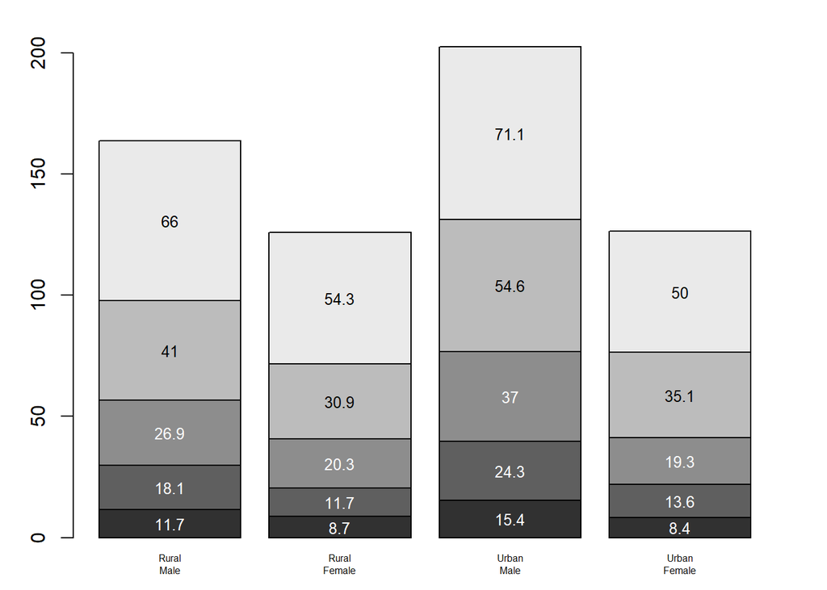

```r
par(mar=c(2, 3.1, 2, 2.1))
midpts <- barplot(VADeaths,
                  col=gray(0.1 + seq(1, 9, 2)/11),
                  names=rep("", 4))
mtext(sub(" ", "\n", colnames(VADeaths)),
      at=midpts, side=1, line=0.5, cex=0.5)
text(rep(midpts, each=5), apply(VADeaths, 2, cumsum) - VADeaths/2,
     VADeaths,
     col=rep(c("white", "black"), times=3:2),
     cex=0.8)
```

```r
par(mar=c(5.1, 4.1, 4.1, 2.1))
```

### Boxplot

Boxwex = Boxwidth at= Change position Subset = Subset of data

boxwex = 0.25, at = 1:3 - 0.2, subset= supp == “VC”, col=“white”, xlab=““, ylab=”tooth length”, ylim=c(0,35))

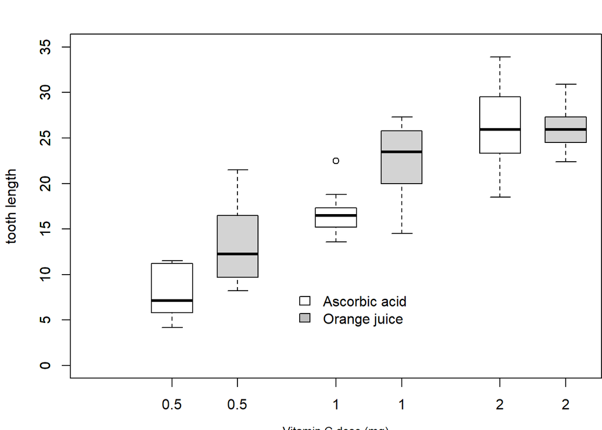

```r
par(mar=c(3, 4.1, 2, 0))
boxplot(len ~ dose, data = ToothGrowth,
        boxwex = 0.25, at = 1:3 - 0.2,
        subset= supp == "VC", col="white",
        xlab="",
        ylab="tooth length", ylim=c(0,35))
mtext("Vitamin C dose (mg)", side=1, line=2.5, cex=0.8)
boxplot(len ~ dose, data = ToothGrowth, add = TRUE,
        boxwex = 0.25, at = 1:3 + 0.2,

        subset= supp == "OJ")
legend(1.5, 9, c("Ascorbic acid", "Orange juice"),
       fill = c("white", "gray"),
       bty="n")
```

```r
par(mar=c(5.1, 4.1, 4.1, 2.1))
```

### Persp

1. z <- outer(x, y, f) Compute the value of function of x,y and store the value as z And adjusted all missing value of z -1
2. f <- function(x,y) { r <- sqrt(x<sup>2+y</sup>2); 10 * sin(r)/r } First derived the distance between x and y by r Then calculate a function of x y by the fraction 10 * sin(r)/r
3. persp(x, y, z, theta = 30, phi = 30, expand = 0.5) Theta = rotated angle of z plane Phi = rotated angle of xy plane Expand = Shrink/ Enlarge the width of the image

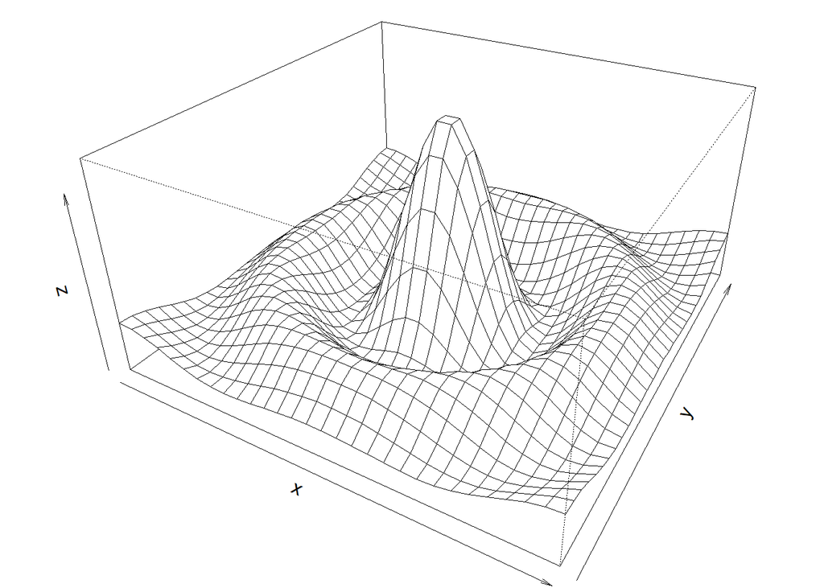

```r
x <- seq(-10, 10, length= 30)
y <- x
f <- function(x,y) { r <- sqrt(x^2+y^2); 10 * sin(r)/r }
z <- outer(x, y, f)
z[is.na(z)] <- 1
# 0.5 to include z axis label
par(mar=c(0, 0.5, 0, 0), lwd=0.5)
persp(x, y, z, theta = 30, phi = 30,
      expand = 0.5)
```

```r
par(mar=c(5.1, 4.1, 4.1, 2.1), lwd=1)
```

### Pie Chart

Can use other type of color pie(pie.sales, col = rainbow(6)) pie(pie.sales, col = heat.colors(6))

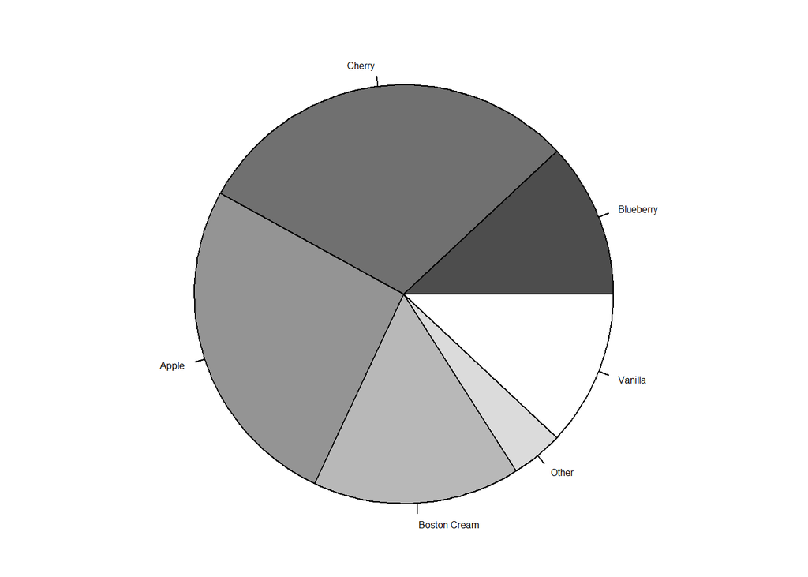

```r
par(mar=c(0, 2, 1, 2), xpd=FALSE, cex=0.5)
pie.sales <- c(0.12, 0.3, 0.26, 0.16, 0.04, 0.12)
names(pie.sales) <- c("Blueberry", "Cherry",
                      "Apple", "Boston Cream", "Other", "Vanilla")
pie(pie.sales, col = gray(seq(0.3,1.0,length=6)))
```

## 2) Using Happy Index

```r
library(readxl)
library(tidyverse)
hpi <- read_excel("HPI_2024_public_dataset.xlsx", sheet = "All Data", skip = 1)
colnames(hpi) <- gsub(" ", "_", colnames(hpi))
colnames(hpi) <- tolower(colnames(hpi))
attach(hpi)
continent <- as.factor(continent)
continent_names <- c("1" = "Latin America", "2" = "N America & Oceania", "3" = "Western Europe", "4" = "Middle East & N. Africa", "5" = "Sub-Saharan Africa", "6" = "South Asia", "7" = "Eastern Europe & Central Asia", "8" = "East Asia")
```

### Test the plot(), points(), lines()

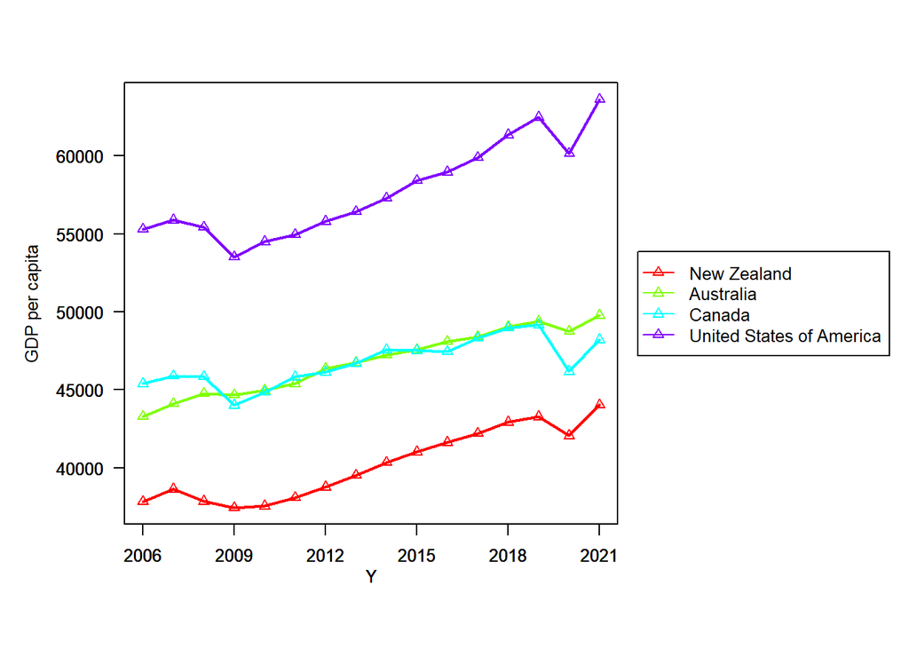

```r
hpi_filtered <- hpi %>% filter(continent == "2")
attach(hpi_filtered)
countries <- unique(country)
par(las=1, mar=c(6, 6, 4, 14), cex=.8, mgp = c(4, 1, 0)) # mgp adjust the gap between axis
plot(year[country == countries[1]], gdp_per_capita[country == countries[1]], type = "n", xlab = "", ylab = "GDP per capita", xlim = c(2006, 2021), ylim = range(gdp_per_capita), xaxt = "n", yaxt= "n") #xaxt and yaxt remove auto axis
colors <- rainbow(length(countries))

for (i in seq_along(countries)) {
  country_data <- hpi_filtered[country == countries[i], ]
  lines(country_data$year, country_data$gdp_per_capita, col = colors[i], lwd = 2)
  points(country_data$year, country_data$gdp_per_capita, col = colors[i], pch = 2, bg = "yellow")
  axis(1, at=seq(2006, 2021, 3))
  axis(2, at=seq(40000, 60000, 5000))
  box(bty="u")
  mtext("Y", side=1, line=2, cex=0.8)
}
legend("right", legend = countries, col = colors, lty = 1, pch = 2, xpd = TRUE, inset = c(-.55, 0)) # legend == picks which variable to display, xpd == TRUE (legnd to be outside the plot)
```

### Histogram

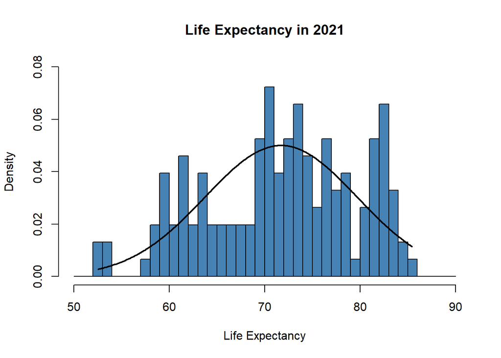

```r
hpi_2021 <- hpi %>% filter(year == "2021", !is.na(lifeexp))
attach(hpi_2021)
mean <- mean(lifeexp)
sd <- sd(lifeexp)
x <- seq(min(lifeexp), max(lifeexp), .1)
dn <- dnorm(x, mean = mean, sd = sd) # Because data is not normally distributed, what need to input the mean and sd to get the line
hist(lifeexp, breaks=seq(50, 90), ylim=c(0, 0.08),
     col="steelblue", freq=FALSE, main = "Life Expectancy in 2021", xlab="Life Expectancy")
lines(x, dn, lwd=2)
```

```r
par(mar=c(5.1, 4.1, 4.1, 2.1))
```

### Boxplot

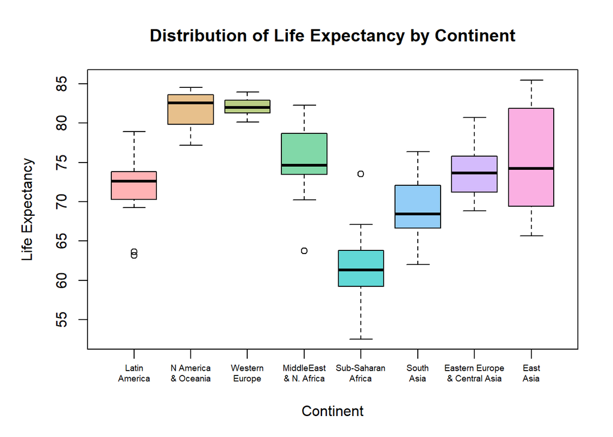

```r
# Given the continent name are too long for displayed, break needs to insert in the categories
continent_names2 <- c("Latin\nAmerica", "N America\n& Oceania", "Western\nEurope", "MiddleEast\n& N. Africa", "Sub-Saharan\nAfrica", "South\nAsia", "Eastern Europe\n& Central Asia", "East\nAsia")

par(mar = c(5, 5, 4, 2))
boxplot(lifeexp ~ continent, data = hpi_2021,
        col = hcl.colors(length(unique(hpi_2021$continent)), palette = "Set3"), # See hcl.colors for more option
        xaxt = "n",
        xlab = "Continent",
        ylab = "Life Expectancy",
        main = "Distribution of Life Expectancy by Continent")
axis(1, at = 1:8, labels = continent_names2, cex.axis=0.6) # cex.axis change font size
```

### Pie chart

```r
attach(hpi_2021)
gdp_mean <- mean(gdp_per_capita, na.rm=TRUE)
hpi_2021_above <- hpi_2021 %>%  filter(gdp_per_capita > gdp_mean)%>% group_by(continent) %>% summarise(country_count = n())
hpi_2021_above # Display the table of continent result
```

```
## # A tibble: 6 × 2
##   continent country_count
##       <dbl>         <int>
## 1         1             4
## 2         2             4
## 3         3            20
## 4         4             7
## 5         7            13
## 6         8             5
```

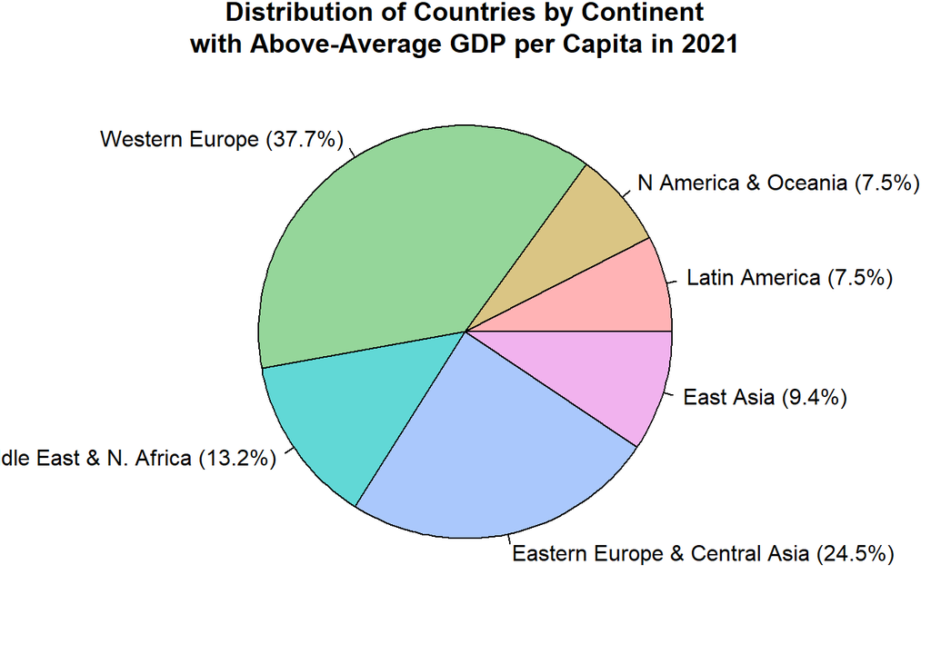

```r
hpi_2021_above$continent <- as.factor(hpi_2021_above$continent)
hpi_2021_above$continent_names <- c("1" = "Latin America", "2" = "N America & Oceania", "3" = "Western Europe", "4" = "Middle East & N. Africa", "7" = "Eastern Europe & Central Asia", "8" = "East Asia")
hpi_2021_above$percentage <- round((hpi_2021_above$country_count / sum(hpi_2021_above$country_count)) * 100, 1)
labels <- paste(hpi_2021_above$continent_names, " (", hpi_2021_above$percentage, "%)", sep = "")
par(mar = c(2, 2, 2, 2)) # Adjust margin to increase pie size
pie(hpi_2021_above$country_count, labels = labels, col = hcl.colors(n = nrow(hpi_2021_above), palette = "Set3"),
    main = "Distribution of Countries by Continent\nwith Above-Average GDP per Capita in 2021")
```

### 3D Perspective Plot

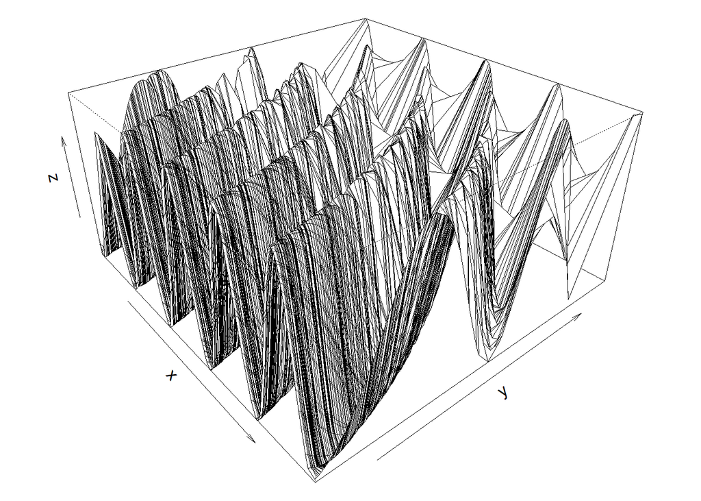

```r
attach(hpi_2021)
x <- sort(unique(na.omit(lifeexp))) # Need to sort x and y so that they are in increasing order, and must be unique to generate f (the distance between x and y)
y <- sort(unique(na.omit(cov_adj_footprint)))
f <- function(x,y) { r <- sqrt(x^2+y^2); 10 * sin(r)/r }
z <- outer(x, y, f)
z[is.na(z)] <- 1
z <- outer(x, y, function(x, y) sin(sqrt(x^2 + y^2)))
par(mar=c(0, 0.5, 0, 0), lwd=0.5)
persp(x, y, z, theta = 50, phi = 30,
      expand = 0.5)
```